# 2x2 repeated measures ANOVA with RS3 data

The following markdown analyses data from the RS3 in R. The results (main effects, interactions and follow up t-tests) are the same as JASP and SPSS.

```r
# rm(list = ls())
library(ggplot2) # data vis
library(tidyr) # data manipulation
library(dplyr) # data manipulation
library(car) # anova and levenes table
library(ggplot2) # plotting interaction plots
library(Rmisc) # for confidence intervals on the interaction plots
library(tidyr) # manipulating dataframes
library(dplyr) # manipulating dataframes
library(ez) # allows me to compute repeated ANOVA that matches JASP output
library(car) # allows me to use Anova() function to get summary of main effects and interactions
library(sjstats) # computes partial eta squared effect size
library(effsize) # computes cohen's D for follow up t-tests
library(apaTables) # for apa tables
library(MBESS) # for apa tables
library(WRS2) # for non-parametric
library(e1071) # for skewness calculation
library(ggpubr) # for interaction plots/boxplots
library(effsize) # for calculating effect sizes
library(compute.es) # ancova using type 3 method
library(multcomp) # post hoc for ancova type 3 method
library(lmPerm) # permutation tests for linear models
library(lme4) # modelling
library(afex) # analysis of factorial experiments
library(lsr) # for calculating partial eta squared

# example dataframe for stack overflow
# dput(head(modellingdata, n = 5))
```

Here I am loading the packages I’ll need for the analysis. I have put a note about why each one is needed. There are many ways to compute ANOVAs in R and there are many different packages you can use to do so. However I have found that the “ez” packages works best for a repeated measures design. I explain in the following markdown.

```r
# work computer working directory
setwd("C:/Users/pscmgo/OneDrive for Business/PhD/Project/Experiment_Code/teachingcode")

# load datset
temp = list.files(pattern = c("RS3_dataset", "*.csv")) # list all CSV files in the directory
myfiles = lapply(temp, read.csv) # read these CSV in the directory
workingdata <- do.call(rbind.data.frame, myfiles) # convert and combine the CSV files into dataframe
```

Here I am grabbing the data from my working directory

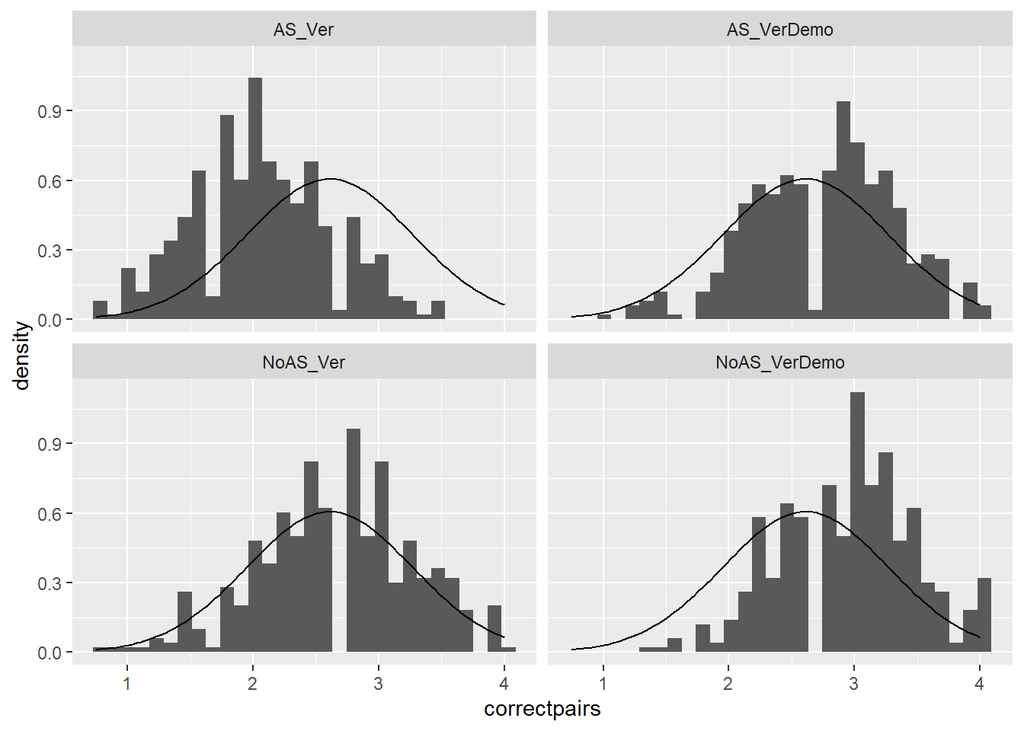

```r
# Here I'm generating a participant ID, this will be important later
workingdata <- workingdata %>%
  dplyr::mutate(ppid = row_number())

# computing histograms and normality curves for each condition
ggplot(workingdata %>%
         gather("NoAS_Ver", "NoAS_VerDemo", "AS_Ver", "AS_VerDemo", key = "condition", value = "correctpairs"), aes(x = correctpairs)) +
  geom_histogram(aes(y = ..density..)) +
  stat_function(
        fun = dnorm,
        args = with(workingdata %>%
                      gather("NoAS_Ver", "NoAS_VerDemo", "AS_Ver", "AS_VerDemo", key = "condition", value = "correctpairs"), c(mean = mean(correctpairs), sd = sd(correctpairs)))) +
  facet_wrap( ~ condition)
```

```r
# descriptives for age
range(workingdata$Age)
```

```
## [1] 18 35
```

```r
mean(workingdata$Age)
```

```
## [1] 19.92584
```

```r
sd(workingdata$Age)
```

```
## [1] 1.886744
```

Firstly I’m creating a new variable “ppid” to indicate the participant number. This will be important when the ANOVA in R attempts to calculate the degrees of freedom.

Histograms are plotted with normal distributions to show how the data is distributed. In this case, things seem fairly normally distributed.

```r
# spliting conditions into factors and their levels
split_data <- workingdata %>%
  gather("NoAS_Ver", "NoAS_VerDemo", "AS_Ver", "AS_VerDemo", key = "condition", value = "correctpairs") %>%
  separate(condition, into = c("task", "presentation"))

head(split_data, n = 5)
```

```
##   Age Gender ppid task presentation correctpairs
## 1  20      1    1 NoAS          Ver        2.125
## 2  20      2    2 NoAS          Ver        3.250
## 3  20      2    3 NoAS          Ver        1.875
## 4  19      1    4 NoAS          Ver        2.625
## 5  19      2    5 NoAS          Ver        3.000
```

```r
tail(split_data, n = 5)
```

```
##      Age Gender ppid task presentation correctpairs
## 1776  19      1  441   AS      VerDemo        3.125
## 1777  19      2  442   AS      VerDemo        2.120
## 1778  19      2  443   AS      VerDemo        1.500
## 1779  19      2  444   AS      VerDemo        3.125
## 1780  22      1  445   AS      VerDemo        3.380
```

```r
# sets our factors as a factor data types
split_data$task <- as.factor(split_data$task)
split_data$presentation <- as.factor(split_data$presentation)
split_data$ppid <- as.factor(split_data$ppid)
```

In JASP, each column represents a condition. In R, I need the columns to refer to the different factors, with each row being an observation. I use the gather function to create a condition and value column. I then use the separate function to seperate the conditions into “task” and “presentation”. The head and tail function demonstrate what this data frame looks like now.

I then ensure the factors in this design are set to factor data types.

```r
# running the ANOVA this way generates the wrong f values and sums of squares
result_wrong <- aov(correctpairs ~ task * presentation, data = split_data)
Anova(result_wrong, type = 3)
```

```
## Anova Table (Type III tests)
##
## Response: correctpairs
##                    Sum Sq   Df  F value    Pr(>F)
## (Intercept)       1892.71    1 5867.679 < 2.2e-16 ***
## task                80.72    1  250.241 < 2.2e-16 ***
## presentation       107.40    1  332.945 < 2.2e-16 ***
## task:presentation   18.50    1   57.343 5.852e-14 ***
## Residuals          572.88 1776
## ---
## Signif. codes:  0 '***' 0.001 '**' 0.01 '*' 0.05 '.' 0.1 ' ' 1
```

This is how I first tried to run the ANOVA. However as you can see, the sum of squares, f values and degrees of freedom (DF) do not match JASP and SPSS output (despite using type 3 sum of squares). After many nights of searching, I realised the problem is the DFs.

```r
nrow(split_data)
```

```
## [1] 1780
```

The DFs are the number of observations that are allowed to vary in the statistical calculation and are calculated as the N - 1. However because I have arranged the dataframe so that each column is a factor, the dataframe is telling the ANOVA that I have 1780 observations. I actually have 445 (the number of participants).

```r
# running the ANOVA this way generates the correc f values and sum of sqaures
result_correct <- ezANOVA(split_data, dv = correctpairs, wid = ppid, within = .(task, presentation), type = 3, detailed = TRUE, return_aov = TRUE)
result_correct
```

```
## $ANOVA
##              Effect DFn DFd         SSn       SSd           F            p
## 1       (Intercept)   1 444 12115.72639 287.90366 18684.66151 0.000000e+00
## 2              task   1 444    70.64509  99.96981   313.75889 1.703071e-53
## 3      presentation   1 444   107.22704  84.41543   563.98226 4.527024e-81
## 4 task:presentation   1 444    18.49669 100.58709    81.64596 5.038954e-18
##   p<.05        ges
## 1     * 0.95485113
## 2     * 0.10977898
## 3     * 0.15766294
## 4     * 0.03127755
##
## $aov
##
## Call:
## aov(formula = formula(aov_formula), data = data)
##
## Grand Mean: 2.608944
##
## Stratum 1: ppid
##
## Terms:
##                 Residuals
## Sum of Squares   287.9037
## Deg. of Freedom       444
##
## Residual standard error: 0.8052526
##
## Stratum 2: ppid:task
##
## Terms:
##                     task Residuals
## Sum of Squares  70.64509  99.96981
## Deg. of Freedom        1       444
##
## Residual standard error: 0.4745074
## 1 out of 2 effects not estimable
## Estimated effects are balanced
##
## Stratum 3: ppid:presentation
##
## Terms:
##                 presentation Residuals
## Sum of Squares     107.22704  84.41543
## Deg. of Freedom            1       444
##
## Residual standard error: 0.4360331
## 1 out of 2 effects not estimable
## Estimated effects are balanced
##
## Stratum 4: ppid:task:presentation
##
## Terms:
##                 task:presentation Residuals
## Sum of Squares           18.49669 100.58709
## Deg. of Freedom                 1       444
##
## Residual standard error: 0.4759701
## Estimated effects are balanced
```

If I use the ezANOVA function, I can specify the number of cases I actually have with the “wid” arugument. I assign this the ppid variable made earlier. This means that the DFs can be correctly calculated, and now the sum of squares (SSn), F value and DFs match the JASP and SPSS output.

Importantly, I input “return_aov = TRUE”. This is important for the effect sizes.

```r
# effect sizes for the correct ANOVA method
eta_sq(result_correct$aov, partial = TRUE)
```

[output not shown]

The effect size function only takes “aov” objects. Because I returned an “aov” object from the ezANOVA, I can use this to calculate the effect size.

```r
model.tables(result_correct$aov, "mean", se = TRUE)
```

```
## Tables of means
## Grand mean
##
## 2.608944
##
##  task
## task
##     AS   NoAS
## 2.4097 2.8082
##
##  presentation
## presentation
##     Ver VerDemo
##  2.3635  2.8544
##
##  task:presentation
##       presentation
## task   Ver    VerDemo
##   AS   2.0623 2.7571
##   NoAS 2.6647 2.9517
```

I then also use the “aov” object from the ezANOVA to calculate the estimated marginal means for the main effects. Again, these match the ones from the SPSS output.

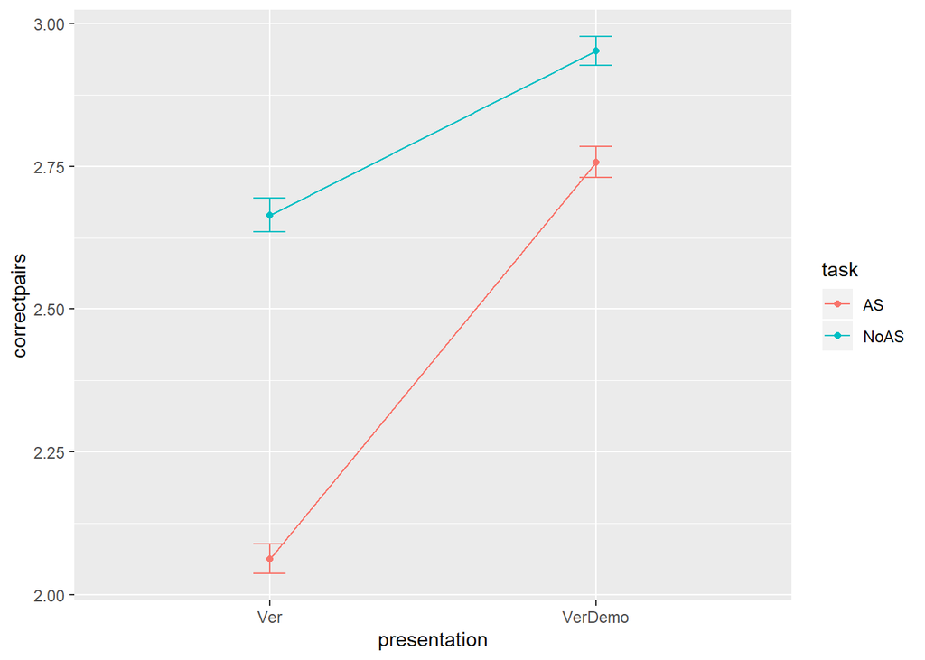

```r
# computes standard error and 95% confidence intervals
CIerror_bar <- summarySE(split_data, measurevar = "correctpairs", groupvars = c("task", "presentation"))

ggplot(data = CIerror_bar, aes(x = presentation, color = task, group = task, y = correctpairs)) +
         stat_summary(fun.y = mean, geom = "point") +
         stat_summary(fun.y = mean, geom = "line") +
  geom_errorbar(aes(ymin = correctpairs - se, ymax = correctpairs + se), width = .1)
```

```r
workingdata <- split_data %>%
  unite("condition", task, presentation, sep = "_") %>%
  spread(condition, correctpairs)
```

To compute the t-tests, I re-order the dataframe so that each condition is a column.

```r
# t-test and effect size for AS and no AS in the verbal condition
t.test(workingdata$NoAS_Ver, workingdata$AS_Ver, paired = TRUE)
```

```
##
##  Paired t-test
##
## data:  workingdata$NoAS_Ver and workingdata$AS_Ver
## t = 18.206, df = 444, p-value < 2.2e-16
## alternative hypothesis: true difference in means is not equal to 0
## 95 percent confidence interval:
##  0.5372949 0.6673343
## sample estimates:
## mean of the differences
##               0.6023146
```

```r
cohen.d(workingdata$NoAS_Ver, workingdata$AS_Ver, paired = TRUE)
```

```
##
## Cohen's d
##
## d estimate: 1.035294 (large)
## 95 percent confidence interval:
##     lower     upper
## 0.8969765 1.1736106
```

```r
# t-test and effect size for AS and no AS in the verbal condition
t.test(workingdata$NoAS_VerDemo, workingdata$AS_VerDemo, paired = TRUE)
```

```
##
##  Paired t-test
##
## data:  workingdata$NoAS_VerDemo and workingdata$AS_VerDemo
## t = 6.3608, df = 444, p-value = 5e-10
## alternative hypothesis: true difference in means is not equal to 0
## 95 percent confidence interval:
##  0.1344469 0.2546767
## sample estimates:
## mean of the differences
##               0.1945618
```

```r
cohen.d(workingdata$NoAS_VerDemo, workingdata$AS_VerDemo, paired = TRUE)
```

```
##
## Cohen's d
##
## d estimate: 0.3506109 (small)
## 95 percent confidence interval:
##     lower     upper
## 0.2391533 0.4620685
```

I can then compute t-tests and cohen’s D effect sizes for AS and no AS in the verbal and and verbal + demo presentation factor levels.

```r
setwd("C:/Users/pscmgo/OneDrive for Business/PhD/Project/Experiment_Code/teachingcode")

apa.2way.table(presentation, task, correctpairs, data = split_data, filename = "anova_means_table.doc", table.number = 1,
  show.conf.interval = TRUE, show.marginal.means = TRUE)
```

```
##
##
## Table 1
##
## Means and standard deviations for correctpairs as a function of a 2(presentation) X 2(task) design
##
##                  M     M_95%_CI   SD
##       task:AS
##  presentation
##           Ver 2.06 [2.01, 2.11] 0.54
##       VerDemo 2.76 [2.70, 2.81] 0.57
##
##     task:NoAS
##  presentation
##           Ver 2.66 [2.61, 2.72] 0.61
##       VerDemo 2.95 [2.90, 3.00] 0.54
##
## Note. M and SD represent mean and standard deviation, respectively.
## LL and UL indicate the lower and upper limits of the
## 95% confidence interval for the mean, respectively.
## The confidence interval is a plausible range of population means
## that could have created a sample mean (Cumming, 2014).
```

```r
apa.ezANOVA.table(result_correct, table.title = "Within subjects effects", table.number = 2, filename = "anova_table.doc")
```

```
##
##
## Table 2
##
## Within subjects effects
##
##            Predictor df_num df_den   SS_num SS_den        F    p ges
##          (Intercept)      1    444 12115.73 287.90 18684.66 .000 .95
##                 task      1    444    70.65  99.97   313.76 .000 .11
##         presentation      1    444   107.23  84.42   563.98 .000 .16
##  task x presentation      1    444    18.50 100.59    81.65 .000 .03
##
## Note. df_num indicates degrees of freedom numerator. df_den indicates degrees of freedom denominator.
## SS_num indicates sum of squares numerator. SS_den indicates sum of squares denominator.
## ges indicates generalized eta-squared.
##
```

Finally, a nice little touch. The apaTables package allows me to save the mean and SDs from the conditions and the ANOVA tables as an APA formatted table in a word document. The package also includes functions that do this for over tests such as regressions and one-way ANOVAs.